[figure not shown]

# Image shuffle

Faisal Qureshi  
Professor  
Faculty of Science  
Ontario Tech University  
Oshawa ON Canada  
http://vclab.science.ontariotechu.ca

## Copyright information

© Faisal Qureshi

## License

This work is licensed under a [Creative Commons Attribution-NonCommercial 4.0 International License](http://creativecommons.org/licenses/by-nc/4.0/).

## Outline

- Numpy arrays and OpenCV images

```python
import cv2 as cv
import numpy as np
import scipy as sp
from scipy import signal
import matplotlib.pyplot as plt
```

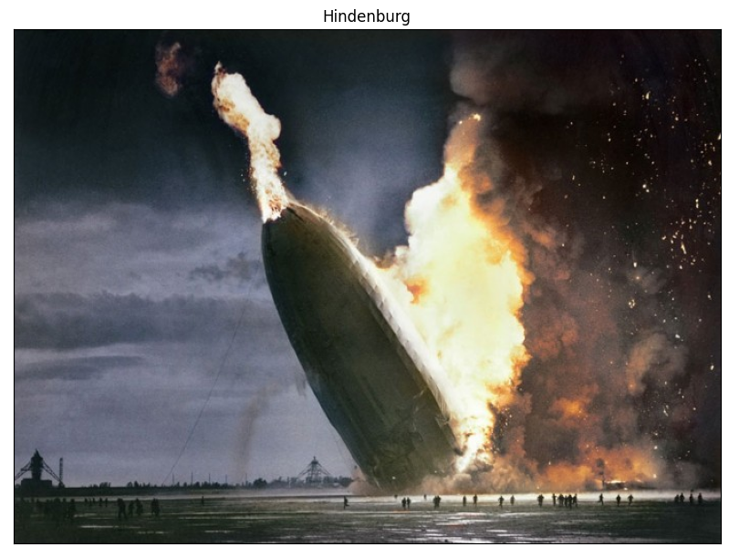

```python
img = cv.imread('data/hindenburg.jpg')
img = cv.cvtColor(img, cv.COLOR_BGR2RGB)

plt.figure(figsize=(10,10))
plt.title('Hindenburg')
plt.imshow(img)
plt.xticks([])
plt.yticks([])
plt.show()
```

## Task 1: Cut image into strips

Below, we have cut the image into 15 strips, indexed from 0 to 14.

[figure not shown]

[figure not shown]

```python
# Your work goes here
plt.rcParams["figure.figsize"] = [7.5, 3.5] # Subplot fixed size

w = img.shape[1]
strp_w = int(w / 15)
cur_w = 0
strps = []

for i in range(15):
    if i == 14:
        strp = img[:, cur_w:-1]
    else:
        strp = img[:, cur_w:cur_w + strp_w]
        cur_w = cur_w + strp_w

    strps.append(strp)

    plt.subplot(1, 15, i+1)
    plt.title(i)
    plt.xticks([])
    plt.yticks([])
    plt.imshow(strp)

plt.show()
```

## Task 2: Shuffle the strips

Shuffle the image strips that you have constructed in the previous task. As shown below.

[figure not shown]

[figure not shown]

```python
# Your work goes here
from random import shuffle

shff_strps = strps.copy()
shuffle(shff_strps)

for i in range(15):
    plt.subplot(1, 15, i+1)
    plt.title(i)
    plt.xticks([])
    plt.yticks([])
    plt.imshow(shff_strps[i])

plt.show()
```

## Task 3: Reconstruct the image

Now reconstruct the original given a shuffled list of strips.

### Solution sketch

In order to reconstruct the original image, you'll need to examine the boundary pixels of various patches. Patches whose boundary pixels "match scores" are high are more likely to be neighbouring patches. One way to compute match scores is to treat each boundary as a real-valued vector. Then the problem is simply to compute the similarity between two vectors. I encourage you to use Euclidean distance and Cosine similarity to see if two vectors (i.e., boundaries) are similar.

Mathematically, say $\mathbf{x}_i$ and $\mathbf{x}_j$ are two vectors representing boundaries of two patches. We can compute the similarity between these two vectors as follows.

#### Euclidean distance

$$ \text{Euclidean-distance }(\mathbf{x}_i,\mathbf{x}_j) = \sqrt{\| \mathbf{x}_i - \mathbf{x}_j \|^2} $$

#### Cosine similarity

$$ \text{Cosine-similarity }(\mathbf{x}_i,\mathbf{x}_j) = \frac{\mathbf{x}_i^T \mathbf{x}_j}{\|\mathbf{x}_i\| \| \mathbf{x}_j\| } $$

### Concerns about efficiency

I encourage you to think of ways on how to reconstruct the image efficiently.